# `PYTHON NOTES: V25.01.08`

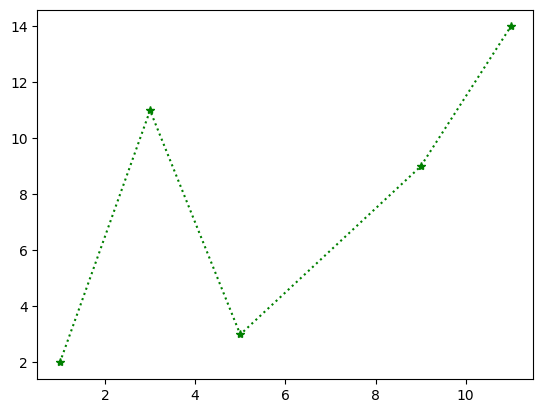

```python
import matplotlib.pyplot as pt
import numpy as np
x = np.array([1,3,5,9,11])
y = np.array([2,11,3,9,14])
pt.plot(x,y,'*:g')
pt.show()
```

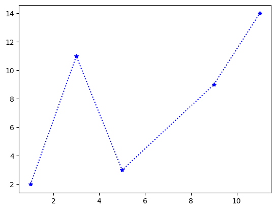

```python
import matplotlib.pyplot as pt
import numpy as np
x = np.array([1,3,5,9,11])
y = np.array([2,11,3,9,14])
pt.plot(x,y,'*:b')
pt.show()
```

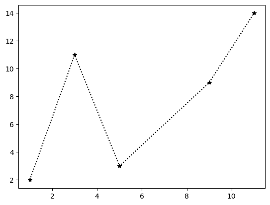

```python
import matplotlib.pyplot as pt
import numpy as np
x = np.array([1,3,5,9,11])
y = np.array([2,11,3,9,14])
pt.plot(x,y,'*:k')
pt.show()
```

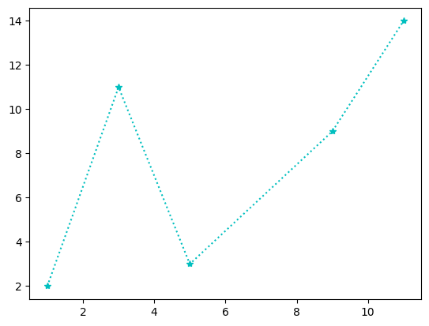

```python
import matplotlib.pyplot as pt
import numpy as np
x = np.array([1,3,5,9,11])
y = np.array([2,11,3,9,14])
pt.plot(x,y,'*:c')
pt.show()
```

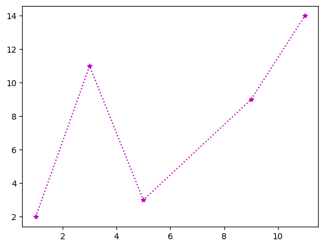

```python
import matplotlib.pyplot as pt
import numpy as np
x = np.array([1,3,5,9,11])
y = np.array([2,11,3,9,14])
pt.plot(x,y,'*:m')
pt.show()
```

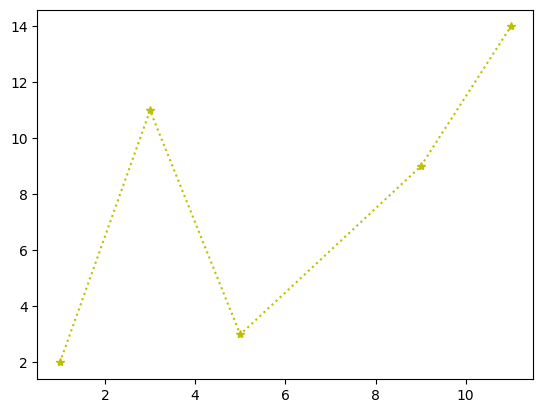

```python
import matplotlib.pyplot as pt
import numpy as np
x = np.array([1,3,5,9,11])
y = np.array([2,11,3,9,14])
pt.plot(x,y,'*:y')
pt.show()
```

- `Line Style:`
1. `Dashed Line:`

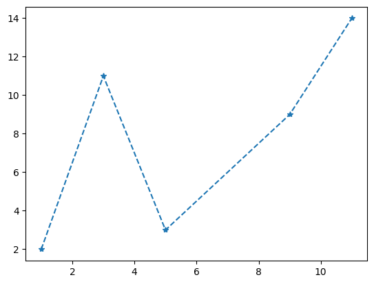

```python
import matplotlib.pyplot as pt
import numpy as np
x = np.array([1,3,5,9,11])
y = np.array([2,11,3,9,14])
pt.plot(x,y,'*--')
pt.show()
```

2. `Double Dashed:`

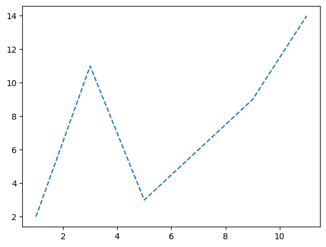

```python
import matplotlib.pyplot as pt
import numpy as np
x = np.array([1,3,5,9,11])
y = np.array([2,11,3,9,14])
pt.plot(x,y,'--')
pt.show()
```

3. `Dotted Line`

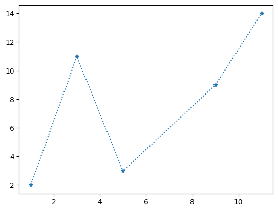

```python
import matplotlib.pyplot as pt
import numpy as np
x = np.array([1,3,5,9,11])
y = np.array([2,11,3,9,14])
pt.plot(x,y,'*:')
pt.show()
```

- `Dashed Dotted:`

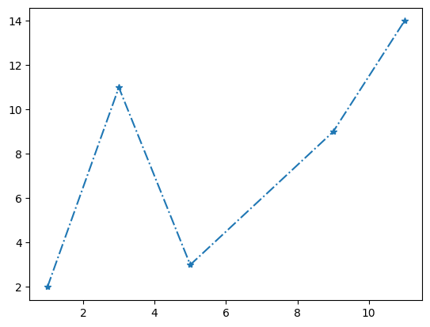

```python
import matplotlib.pyplot as pt
import numpy as np
x = np.array([1,3,5,9,11])
y = np.array([2,11,3,9,14])
pt.plot(x,y,'*-.')
pt.show()
```

- `Marker Size: (ms)`

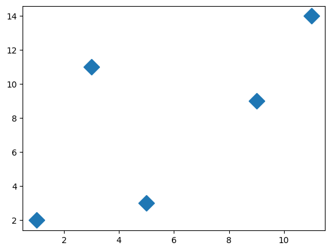

```python
import matplotlib.pyplot as pt
import numpy as np
x = np.array([1,3,5,9,11])
y = np.array([2,11,3,9,14])
pt.plot(x,y,'D',ms=13.3)
pt.show()
```

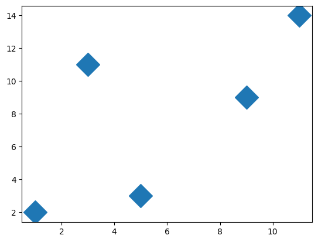

```python
import matplotlib.pyplot as pt
import numpy as np
x = np.array([1,3,5,9,11])
y = np.array([2,11,3,9,14])
pt.plot(x,y,'D',ms=20.4)
pt.show()
```

- `Marker Heilighter Color: (mec)`

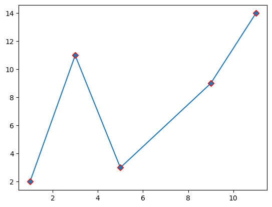

```python
import matplotlib.pyplot as pt
import numpy as np
x = np.array([1,3,5,9,11])
y = np.array([2,11,3,9,14])
pt.plot(x,y,marker='D',mec='r')
pt.show()
```

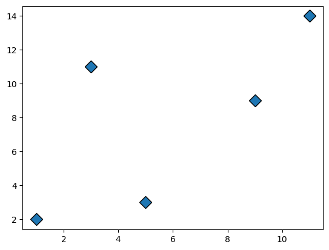

```python
import matplotlib.pyplot as pt
import numpy as np
x = np.array([1,3,5,9,11])
y = np.array([2,11,3,9,14])
pt.plot(x,y,'D',ms=10,mec='k')
pt.show()
```

- `Marker Facce Color: (mfc)`

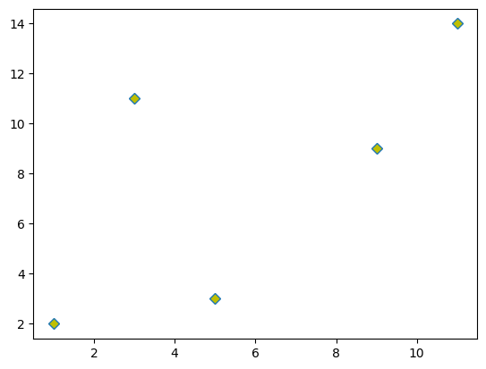

```python
import matplotlib.pyplot as pt
import numpy as np
x = np.array([1,3,5,9,11])
y = np.array([2,11,3,9,14])
pt.plot(x,y,'D',mfc='y')
pt.show()
```

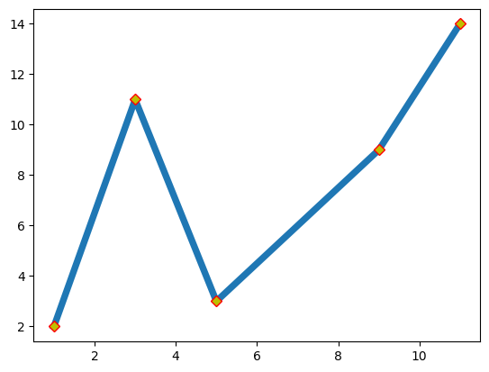

```python
import matplotlib.pyplot as pt
import numpy as np
x = np.array([1,3,5,9,11])
y = np.array([2,11,3,9,14])
pt.plot(x,y,marker='D',mec='r',mfc='y',linewidth=5.3)
pt.show()
```

- `Grid: It provides Symmetrical graph as a background.`

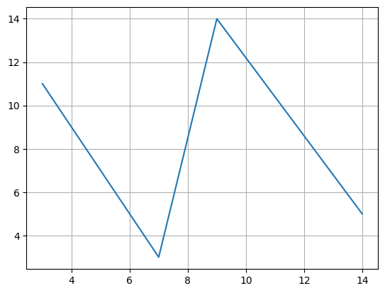

```python
import matplotlib.pyplot as pt
import numpy as np
x = np.array([3,7,9,14])
y = np.array([11,3,14,5])
pt.plot(x,y)
pt.grid()
pt.show()
```

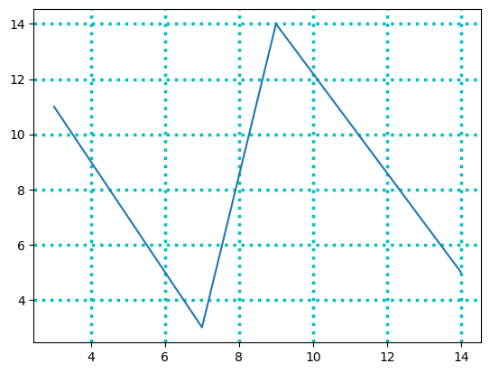

```python
import matplotlib.pyplot as pt
import numpy as np
x = np.array([3,7,9,14])
y = np.array([11,3,14,5])
pt.plot(x,y)
pt.grid(c='c',ls=':',linewidth='2.5')
pt.show()
```

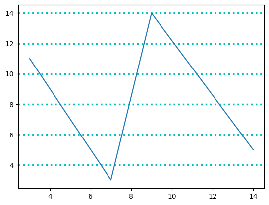

```python
import matplotlib.pyplot as pt
import numpy as np
x = np.array([3,7,9,14])
y = np.array([11,3,14,5])
pt.plot(x,y)
pt.grid(c='c',ls=':',linewidth='2.5',axis='y')
pt.show()
```

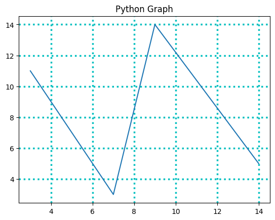

```python
import matplotlib.pyplot as pt
import numpy as np
x = np.array([3,7,9,14])
y = np.array([11,3,14,5])
pt.plot(x,y)
pt.grid(c='c',ls=':',linewidth='2.5')
pt.title("Python Graph")
pt.show()
```

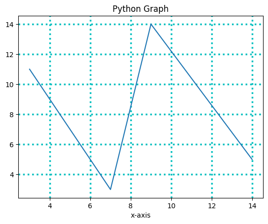

```python
import matplotlib.pyplot as pt
import numpy as np
x = np.array([3,7,9,14])
y = np.array([11,3,14,5])
pt.plot(x,y)
pt.grid(c='c',ls=':',linewidth='2.5')
pt.title("Python Graph")
pt.xlabel("x-axis")
pt.show()
```

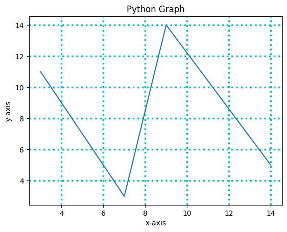

```python
import matplotlib.pyplot as pt
import numpy as np
x = np.array([3,7,9,14])
y = np.array([11,3,14,5])
pt.plot(x,y)
pt.grid(c='c',ls=':',linewidth='2.5')
pt.title("Python Graph")
pt.xlabel("x-axis")
pt.ylabel("y-axis")
pt.show()
```

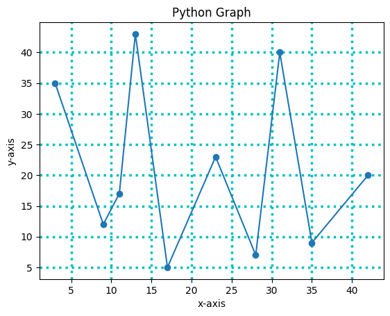

```python
import matplotlib.pyplot as pt
import numpy as np
x = np.array([3,9,11,13,17,23,28,31,35,42])
y = np.array([35,12,17,43,5,23,7,40,9,20])
pt.title("Python Graph")
pt.xlabel("x-axis")
pt.ylabel("y-axis")
pt.plot(x,y,marker='o')
pt.grid(c='c',ls=':',linewidth='2.5')
pt.show()
```

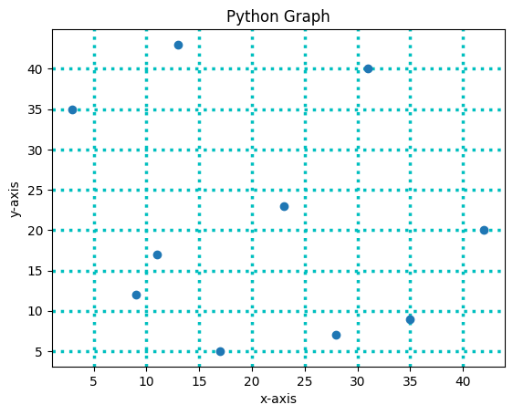

```python
import matplotlib.pyplot as pt
import numpy as np
x = np.array([3,9,11,13,17,23,28,31,35,42])
y = np.array([35,12,17,43,5,23,7,40,9,20])
pt.title("Python Graph")
pt.xlabel("x-axis")
pt.ylabel("y-axis")
pt.plot(x,y,'o')
pt.grid(c='c',ls=':',linewidth='2.5')
pt.show()
```

- `Scatter:`

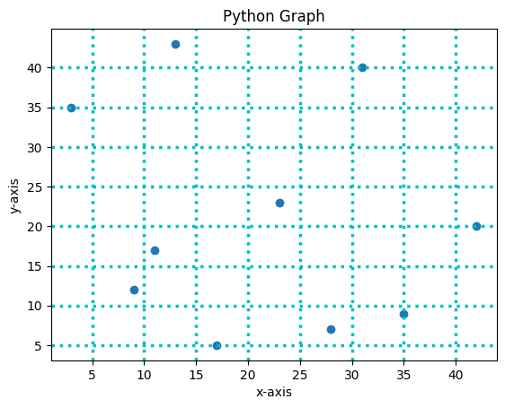

```python
import matplotlib.pyplot as pt
import numpy as np
x = np.array([3,9,11,13,17,23,28,31,35,42])
y = np.array([35,12,17,43,5,23,7,40,9,20])
pt.title("Python Graph")
pt.xlabel("x-axis")
pt.ylabel("y-axis")
pt.scatter(x,y,marker='o')
pt.grid(c='c',ls=':',linewidth='2.5')
pt.show()
```

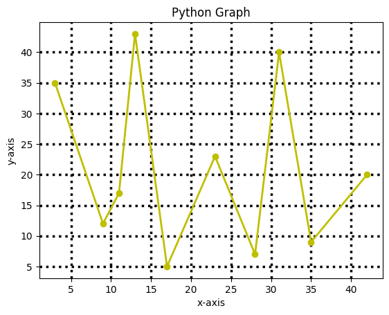

```python
import matplotlib.pyplot as pt
import numpy as np
x = np.array([3,9,11,13,17,23,28,31,35,42])
y = np.array([35,12,17,43,5,23,7,40,9,20])
colors = np.array(['red','green','blue','black','yellow','gray','orange','brown','magenta','cyan'])
pt.title("Python Graph")
pt.xlabel("x-axis")
pt.ylabel("y-axis")
pt.plot(x,y,marker='o',c='y',linewidth=2)
pt.grid(c='k',ls=':',linewidth='2.5')
pt.show()
```

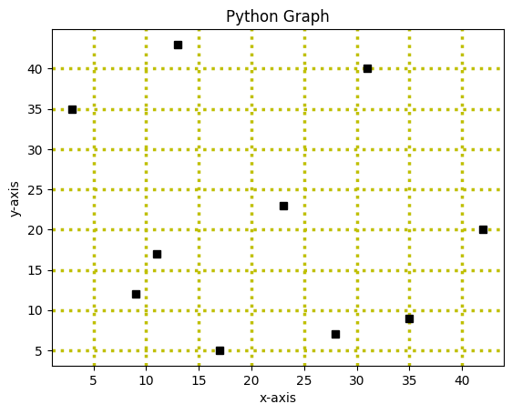

```python
import matplotlib.pyplot as pt
import numpy as np
x = np.array([3,9,11,13,17,23,28,31,35,42])
y = np.array([35,12,17,43,5,23,7,40,9,20])
colors = np.array(['red','green','blue','black','yellow','gray','orange','brown','magenta','cyan'])
pt.title("Python Graph")
pt.xlabel("x-axis")
pt.ylabel("y-axis")
pt.plot(x,y,'s',c='k',linewidth=2)
pt.grid(c='y',ls=':',linewidth='2.5')
pt.show()
```

[figure not shown]

```python
import matplotlib.pyplot as pt
import numpy as np
x = np.array([3,9,11,13,17,23,28,31,35,42])
y = np.array([35,12,17,43,5,23,7,40,9,20])
colors = np.array(['red','green','blue','black','yellow','gray','orange','brown','magenta','cyan'])
pt.title("Python Graph")
pt.xlabel("x-axis")
pt.ylabel("y-axis")
# pt.plot(x,y,marker='o',c='y',linewidth='2')
pt.scatter(x,y,marker='D',)
# pt.grid(c='k',ls=':',linewidth='2.5')
pt.show()
```

## `Matplotlib (subplot) V25.02.13`

- `subplot: syntax: pt.subplot(row,column,position)`

[figure not shown]

```python
import matplotlib.pyplot as pt
import numpy as np
x = np.array([1,3,7,9])
y = np.array([10,3,5,11])
pt.subplot(1,2,1)
pt.title("Graph-1")
pt.plot(x,y)
a = np.array([1,3,7,9])
b = np.array([10,3,5,11])
pt.subplot(1,2,2)
pt.plot(a,b)
pt.title("Graph-2")
pt.tight_layout()
pt.show()
```

[figure not shown]

```python
import matplotlib.pyplot as pt
import numpy as np
x = np.array([1,9,4,8])
y = np.array([3,9,12,5])
pt.subplot(1,3,1)
pt.plot(x,y)
pt.title("Graph-1")
a = np.array([1,9,4,8])
b = np.array([3,9,12,5])
pt.subplot(1,3,2)
pt.plot(a,b)
pt.title("Graph-2")
p = np.array([1,9,4,8])
q = np.array([3,9,12,5])
pt.subplot(1,3,3)
pt.plot(p,q)
pt.title("Graph-3")
pt.tight_layout()
pt.show()
```

[figure not shown]

```python
import matplotlib.pyplot as pt
import numpy as np
x = np.array([1,3,5])
y = np.array([10,7,14])
pt.subplot(2,1,1)
pt.plot(x,y)
pt.title("Graph-1")
a = np.array([1,3,5])
b = np.array([10,7,14])
pt.subplot(2,1,2)
pt.plot(a,b)
pt.title("Graph-2")
pt.tight_layout()
pt.show()
```

- `Demo` `Experiment`

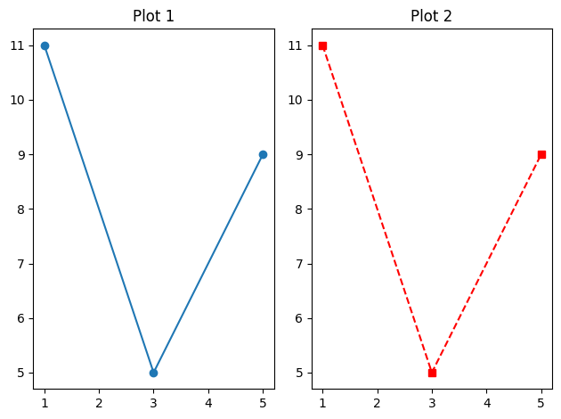

```python
import matplotlib.pyplot as pt
import numpy as np

x = np.array([1, 3, 5])
y = np.array([11, 5, 9])

# First subplot (1 row, 2 columns, 1st plot)
pt.subplot(1, 2, 1)
pt.plot(x, y, marker='o', linestyle='-')
pt.title("Plot 1")

a = np.array([1, 3, 5])
b = np.array([11, 5, 9])

# Second subplot (1 row, 2 columns, 2nd plot)
pt.subplot(1, 2, 2)
pt.plot(a, b, marker='s', linestyle='--', color='red')
pt.title("Plot 2")

# Show all plots together
pt.tight_layout()  # Adjust layout for better spacing
pt.show()
```

[figure not shown]

```python
import matplotlib.pyplot as pt
import numpy as np
x = np.array([1,3,5])
y = np.array([11,5,9])
pt.subplot(1,2,1)
pt.plot(x,y)
pt.title("Graph-1")
a = np.array([1,3,5])
b = np.array([11,5,9])
pt.subplot(1,2,2)
pt.plot(x,y)
pt.title("Graph-2")
pt.tight_layout()
pt.show()
```

[figure not shown]

```python
import matplotlib.pyplot as pt
import numpy as np
x = np.array([1,3,5])
y = np.array([11,5,9])
pt.subplot(2,1,1)
pt.plot(x,y)
pt.title("Graph-1")
a = np.array([1,3,5])
b = np.array([11,5,9])
pt.subplot(2,1,2)
pt.plot(x,y)
pt.title("Graph-2")
pt.tight_layout()
pt.show()
```

[figure not shown]

```python
import matplotlib.pyplot as pt
import numpy as np
x = np.array([1,3,5])
y = np.array([11,7,3])
pt.subplot(3,1,1)
pt.plot(x,y)
pt.title("Graph-1")
a = np.array([1,3,5])
b = np.array([11,7,3])
pt.subplot(3,1,2)
pt.plot(x,y)
pt.title("Graph-2")
p = np.array([1,3,5])
q = np.array([11,7,3])
pt.subplot(3,1,3)
pt.plot(x,y)
pt.title("Graph-3")
pt.tight_layout()
pt.show()
```

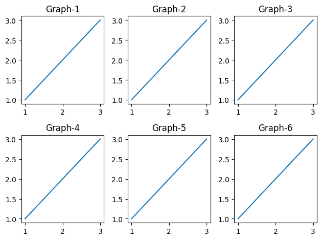

```python
import matplotlib.pyplot as pt
import numpy as np
a = np.array([1,2,3])
b = np.array([1,2,3])
pt.subplot(2,3,1)
pt.plot(a,b)
pt.title("Graph-1")
c = np.array([1,2,3])
d = np.array([1,2,3])
pt.subplot(2,3,2)
pt.plot(c,d)
pt.title("Graph-2")
e = np.array([1,2,3])
f = np.array([1,2,3])
pt.subplot(2,3,3)
pt.plot(e,f)
pt.title("Graph-3")
g = np.array([1,2,3])
h = np.array([1,2,3])
pt.subplot(2,3,4)
pt.plot(g,h)
pt.title("Graph-4")
i = np.array([1,2,3])
j = np.array([1,2,3])
pt.subplot(2,3,5)
pt.plot(i,j)
pt.title("Graph-5")
k = np.array([1,2,3])
l = np.array([1,2,3])
pt.subplot(2,3,6)
pt.plot(k,l)
pt.title("Graph-6")
pt.tight_layout()
pt.show()
```

## `Bar Graph`

- `Bar Graph: syntax: pt.bar(x,y)`
- `Verticle: Bar: Accepts width`
- `Horizontal: Barh: Accepts Height`
- `Default height and width of bar is 0.8.`
- `Bar Graph: Separate Bars`
- `Histogram Graph: Joint Bars. Use S.D.`

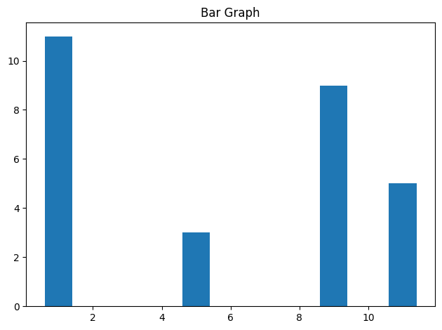

```python
import matplotlib.pyplot as pt
import numpy as np
x = np.array([1,5,9,11])
y = np.array([11,3,9,5])
pt.bar(x,y)
pt.title("Bar Graph")
pt.tight_layout()
pt.show()
```

- `bar : width`

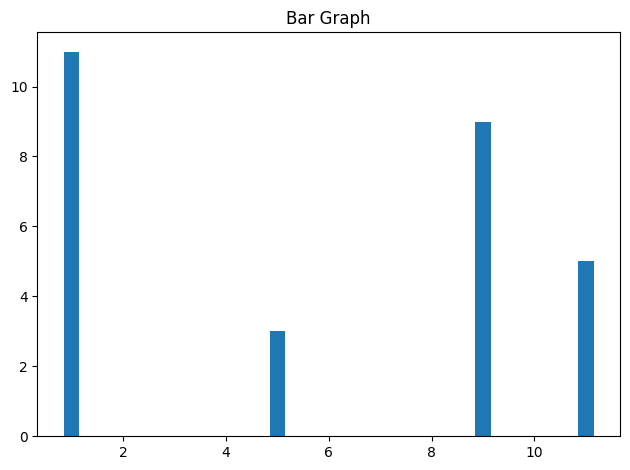

```python
import matplotlib.pyplot as pt
import numpy as np
x = np.array([1,5,9,11])
y = np.array([11,3,9,5])
pt.bar(x,y,width=0.3)
pt.title("Bar Graph")
pt.tight_layout()
pt.show()
```

- `barh : height`

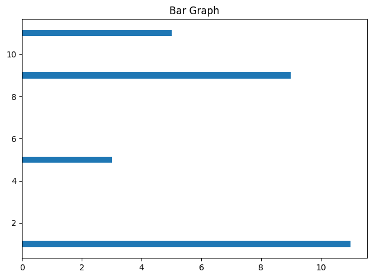

```python
import matplotlib.pyplot as pt
import numpy as np
x = np.array([1,5,9,11])
y = np.array([11,3,9,5])
pt.barh(x,y,height=0.3)
pt.title("Bar Graph")
pt.tight_layout()
pt.show()
```

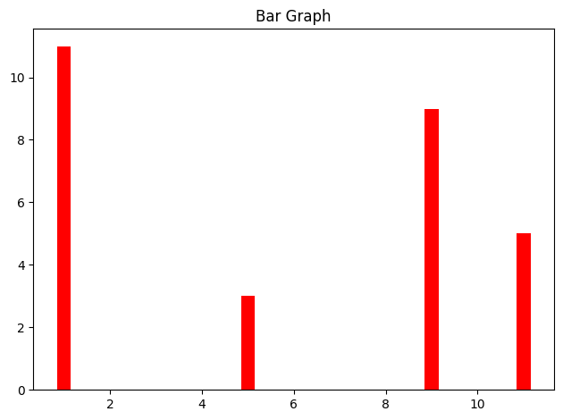

```python
import matplotlib.pyplot as pt
import numpy as np
x = np.array([1,5,9,11])
y = np.array([11,3,9,5])
pt.bar(x,y,width=0.3, color='red')
pt.title("Bar Graph")
pt.tight_layout()
pt.show()
```

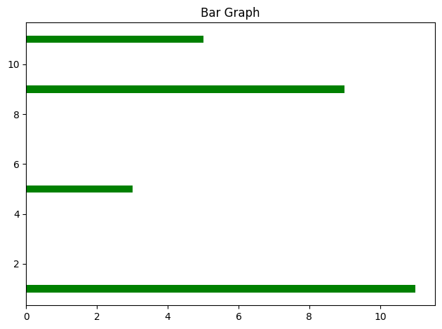

```python
import matplotlib.pyplot as pt
import numpy as np
x = np.array([1,5,9,11])
y = np.array([11,3,9,5])
pt.barh(x,y,height=0.3,color='green')
pt.title("Bar Graph")
pt.tight_layout()
pt.show()
```

## `Pie Graph:`

- `O degree`
- `Anticlockwise`
- `Position = Specific Value / Total Addition of all Values`
- `Default colors: blue, orange, green, red.`

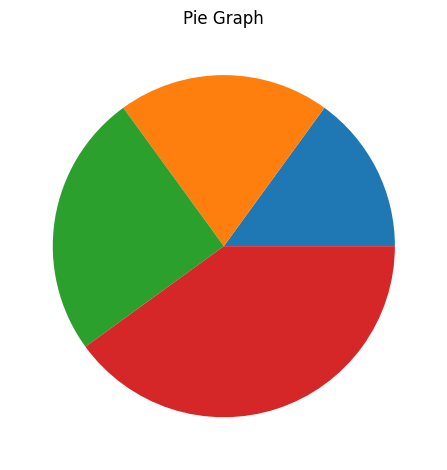

```python
import matplotlib.pyplot as pt
import numpy as np
x = np.array([15,20,25,40])
pt.pie(x)
pt.title("Pie Graph")
pt.tight_layout()
pt.show()
```

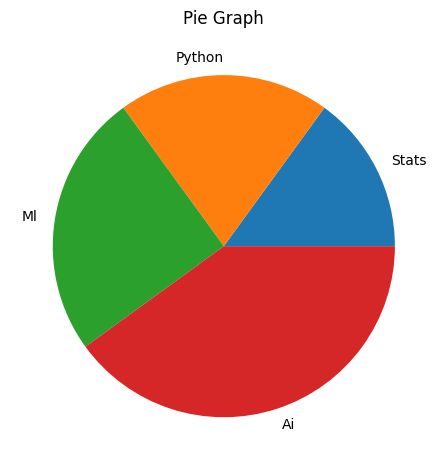

```python
import matplotlib.pyplot as pt
import numpy as np
x = np.array([15,20,25,40])
users = np.array(["Stats","Python","Ml","Ai"])
pt.pie(x,labels=users)
pt.title("Pie Graph")
pt.tight_layout()
pt.show()
```

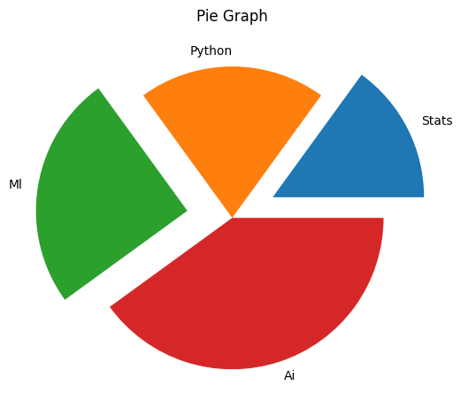

```python
import matplotlib.pyplot as pt
import numpy as np
x = np.array([15,20,25,40])
users = np.array(["Stats","Python","Ml","Ai"])
ex = np.array([0.3,0,0.3,0])
pt.pie(x,labels=users,explode=ex)
pt.title("Pie Graph")
pt.tight_layout()
pt.show()
```

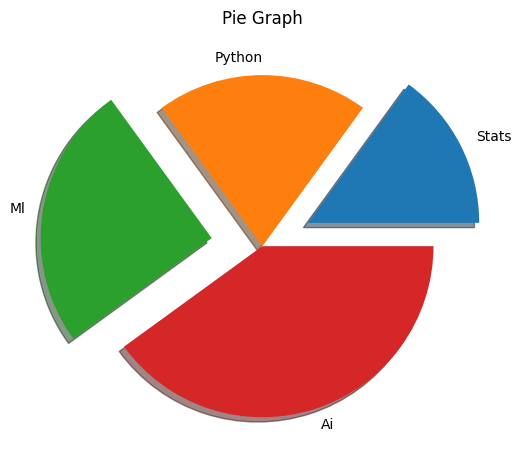

```python
import matplotlib.pyplot as pt
import numpy as np
x = np.array([15,20,25,40])
users = np.array(["Stats","Python","Ml","Ai"])
ex = np.array([0.3,0,0.3,0])
pt.pie(x,labels=users,explode=ex, shadow=True)
pt.title("Pie Graph")
pt.tight_layout()
pt.show()
```

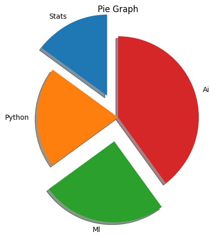

```python
import matplotlib.pyplot as pt
import numpy as np
x = np.array([15,20,25,40])
users = np.array(["Stats","Python","Ml","Ai"])
ex = np.array([0.3,0,0.3,0])
pt.pie(x, labels=users, explode=ex, shadow=True, startangle=90)
pt.title("Pie Graph")
pt.tight_layout()
pt.show()
```

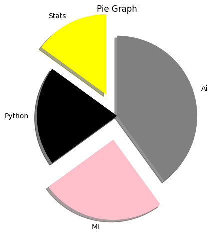

```python
import matplotlib.pyplot as pt
import numpy as np
x = np.array([15,20,25,40])
users = np.array(["Stats","Python","Ml","Ai"])
ex = np.array([0.3,0,0.3,0])
colors = np.array(["yellow","black","pink","grey"])
pt.pie(x, labels=users, explode=ex, shadow=True, startangle=90, colors=colors)
pt.title("Pie Graph")
pt.tight_layout()
pt.show()
```

## `Panda`

- `Python Library(Packase) for Data Operations.`
- `import panda as pd`
- `mostly supports csv files`
- `DataFrames: Return 1st and last 5 Records of data`
- `Path: Download -> move to desktop -> Right click -> Properties -> Copy path`
- `pd.read_csv("Path") (convert (\)Backslash -> (/)Forwordslash and add file name with .csv) eg,. C:/Users/majag/Desktop/data.csv`
- `.to_string(): Return all data`
- `.info(): Information of File`
- `.plot`

```python
pip install pandas
```

[output not shown]

```python
pip install --upgrade pip
```

[output not shown]

```python
import pandas as pd
# path1 = C:\Users\majag\Desktop\GitHub ⚒️\Python ⚒️
# path2 = C:\Users\majag\Desktop
data = pd.read_csv("C:/Users/majag/Desktop/data.csv")
view = pd.DataFrame(data)
print(view)
```

```
     Duration  Pulse  Maxpulse  Calories
0          60    110       130     409.1
1          60    117       145     479.0
2          60    103       135     340.0
3          45    109       175     282.4
4          45    117       148     406.0
..        ...    ...       ...       ...
164        60    105       140     290.8
165        60    110       145     300.0
166        60    115       145     310.2
167        75    120       150     320.4
168        75    125       150     330.4

[169 rows x 4 columns]
```

```python
import pandas as pd
# path1 = C:\Users\majag\Desktop\GitHub ⚒️\Python ⚒️
# path2 = C:\Users\majag\Desktop
data = pd.read_csv("C:/Users/majag/Desktop/data.csv")
view = pd.DataFrame(data)
print(view.to_string())
```

```
     Duration  Pulse  Maxpulse  Calories
0          60    110       130     409.1
1          60    117       145     479.0
2          60    103       135     340.0
3          45    109       175     282.4
4          45    117       148     406.0
5          60    102       127     300.0
6          60    110       136     374.0
7          45    104       134     253.3
8          30    109       133     195.1
9          60     98       124     269.0
10         60    103       147     329.3
11         60    100       120     250.7
12         60    106       128     345.3
13         60    104       132     379.3
```

[output cut: 155 more lines]

```python
import pandas as pd
# path1 = C:\Users\majag\Desktop\GitHub ⚒️\Python ⚒️
# path2 = C:\Users\majag\Desktop
data = pd.read_csv("C:/Users/majag/Desktop/data.csv")
view = pd.DataFrame(data)
print(view.info())
```

```
<class 'pandas.core.frame.DataFrame'>
RangeIndex: 169 entries, 0 to 168
Data columns (total 4 columns):
 #   Column    Non-Null Count  Dtype
---  ------    --------------  -----
 0   Duration  169 non-null    int64
 1   Pulse     169 non-null    int64
 2   Maxpulse  169 non-null    int64
 3   Calories  164 non-null    float64
dtypes: float64(1), int64(3)
memory usage: 5.4 KB
None
```

```
Axes(0.125,0.11;0.775x0.77)
```

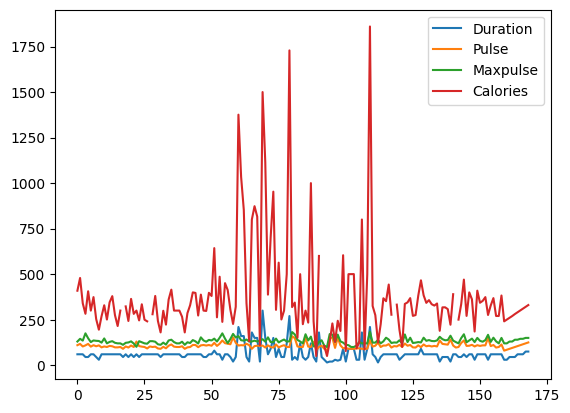

```python
import pandas as pd
# path1 = C:\Users\majag\Desktop\GitHub ⚒️\Python ⚒️
# path2 = C:\Users\majag\Desktop
data = pd.read_csv("C:/Users/majag/Desktop/data.csv")
view = pd.DataFrame(data)
print(view.plot())
```

# `math library`

```python
import math
print(math.pi)
print(math.e)
print(math.sqrt(25))
print(math.sqrt(17))
print(math.isqrt(17))
print(math.fabs(17.9))
# Absolute value: Returning Positive Value.
print(math.ceil(31.9))
print(math.ceil(-31.9))
print(math.floor(31.9))
print(math.floor(-31.9))
```

```
3.141592653589793
2.718281828459045
5.0
4.123105625617661
4
17.9
32
-31
31
-32
```

- `Scripting language: Everithing consideras a String. (Numbers also).`
- `By default in Input function everything consider as String. explicitly we have to convetit into numbers or any other value.`
- `Python is scripting language that's why it is use for web devlopment.`